# Risk Factor Analysis

## Outcome Variable

**Outcome Variable:** wast_rec90d

## Predictor Variables

**Intervention Variable:** gagebrth

**Adjustment Set:**

- arm
- sex
- W_mage
- meducyrs
- feducyrs
- hhwealth_quart
- W_nrooms
- W_nchldlt5
- brthmon
- W_parity
- impfloor
- impsan
- safeh20
- delta_W_mage
- delta_meducyrs
- delta_feducyrs
- delta_hhwealth_quart
- delta_W_nrooms
- delta_W_nchldlt5
- delta_brthmon
- delta_W_parity
- delta_impfloor
- delta_impsan
- delta_safeh20

## Stratifying Variables

The analysis was stratified on these variable(s):

- agecat
- studyid
- country

## Data Summary

| agecat | studyid | country | gagebrth | wast_rec90d | n_cell | n |
| --- | --- | --- | --- | --- | --- | --- |
| 0-24 months | ki1000108-CMC-V-BCS-2002 | INDIA | Full or late term | 0 | 68 | 301 |
| 0-24 months | ki1000108-CMC-V-BCS-2002 | INDIA | Full or late term | 1 | 119 | 301 |
| 0-24 months | ki1000108-CMC-V-BCS-2002 | INDIA | Preterm | 0 | 21 | 301 |
| 0-24 months | ki1000108-CMC-V-BCS-2002 | INDIA | Preterm | 1 | 28 | 301 |
| 0-24 months | ki1000108-CMC-V-BCS-2002 | INDIA | Early term | 0 | 21 | 301 |
| 0-24 months | ki1000108-CMC-V-BCS-2002 | INDIA | Early term | 1 | 44 | 301 |
| 0-24 months | ki1000108-IRC | INDIA | Full or late term | 0 | 92 | 382 |
| 0-24 months | ki1000108-IRC | INDIA | Full or late term | 1 | 134 | 382 |
| 0-24 months | ki1000108-IRC | INDIA | Preterm | 0 | 24 | 382 |
| 0-24 months | ki1000108-IRC | INDIA | Preterm | 1 | 29 | 382 |
| 0-24 months | ki1000108-IRC | INDIA | Early term | 0 | 39 | 382 |
| 0-24 months | ki1000108-IRC | INDIA | Early term | 1 | 64 | 382 |
| 0-24 months | ki1000109-EE | PAKISTAN | Full or late term | 0 | 8 | 514 |
| 0-24 months | ki1000109-EE | PAKISTAN | Full or late term | 1 | 12 | 514 |
| 0-24 months | ki1000109-EE | PAKISTAN | Preterm | 0 | 196 | 514 |
| 0-24 months | ki1000109-EE | PAKISTAN | Preterm | 1 | 156 | 514 |
| 0-24 months | ki1000109-EE | PAKISTAN | Early term | 0 | 96 | 514 |
| 0-24 months | ki1000109-EE | PAKISTAN | Early term | 1 | 46 | 514 |
| 0-24 months | ki1000304b-SAS-CompFeed | INDIA | Full or late term | 0 | 9 | 810 |
| 0-24 months | ki1000304b-SAS-CompFeed | INDIA | Full or late term | 1 | 5 | 810 |
| 0-24 months | ki1000304b-SAS-CompFeed | INDIA | Preterm | 0 | 463 | 810 |
| 0-24 months | ki1000304b-SAS-CompFeed | INDIA | Preterm | 1 | 282 | 810 |
| 0-24 months | ki1000304b-SAS-CompFeed | INDIA | Early term | 0 | 29 | 810 |
| 0-24 months | ki1000304b-SAS-CompFeed | INDIA | Early term | 1 | 22 | 810 |
| 0-24 months | ki1017093c-NIH-Crypto | BANGLADESH | Full or late term | 0 | 16 | 311 |
| 0-24 months | ki1017093c-NIH-Crypto | BANGLADESH | Full or late term | 1 | 26 | 311 |
| 0-24 months | ki1017093c-NIH-Crypto | BANGLADESH | Preterm | 0 | 57 | 311 |
| 0-24 months | ki1017093c-NIH-Crypto | BANGLADESH | Preterm | 1 | 92 | 311 |
| 0-24 months | ki1017093c-NIH-Crypto | BANGLADESH | Early term | 0 | 44 | 311 |
| 0-24 months | ki1017093c-NIH-Crypto | BANGLADESH | Early term | 1 | 76 | 311 |

[output cut: 186 more lines]

The following strata were considered:

- agecat: 0-24 months, studyid: ki1000108-CMC-V-BCS-2002, country: INDIA
- agecat: 0-24 months, studyid: ki1000108-IRC, country: INDIA
- agecat: 0-24 months, studyid: ki1000109-EE, country: PAKISTAN
- agecat: 0-24 months, studyid: ki1000304b-SAS-CompFeed, country: INDIA
- agecat: 0-24 months, studyid: ki1017093c-NIH-Crypto, country: BANGLADESH
- agecat: 0-24 months, studyid: ki1066203-TanzaniaChild2, country: TANZANIA, UNITED REPUBLIC OF
- agecat: 0-24 months, studyid: ki1101329-Keneba, country: GAMBIA
- agecat: 0-24 months, studyid: ki1119695-PROBIT, country: BELARUS
- agecat: 0-24 months, studyid: ki1135781-COHORTS, country: GUATEMALA
- agecat: 0-24 months, studyid: ki1135781-COHORTS, country: INDIA
- agecat: 0-24 months, studyid: ki1135781-COHORTS, country: PHILIPPINES
- agecat: 0-24 months, studyid: kiGH5241-JiVitA-3, country: BANGLADESH
- agecat: 0-6 months, studyid: ki1000108-CMC-V-BCS-2002, country: INDIA
- agecat: 0-6 months, studyid: ki1000108-IRC, country: INDIA
- agecat: 0-6 months, studyid: ki1000109-EE, country: PAKISTAN
- agecat: 0-6 months, studyid: ki1000304b-SAS-CompFeed, country: INDIA
- agecat: 0-6 months, studyid: ki1017093c-NIH-Crypto, country: BANGLADESH
- agecat: 0-6 months, studyid: ki1066203-TanzaniaChild2, country: TANZANIA, UNITED REPUBLIC OF
- agecat: 0-6 months, studyid: ki1101329-Keneba, country: GAMBIA
- agecat: 0-6 months, studyid: ki1119695-PROBIT, country: BELARUS
- agecat: 0-6 months, studyid: ki1135781-COHORTS, country: GUATEMALA
- agecat: 0-6 months, studyid: ki1135781-COHORTS, country: INDIA
- agecat: 0-6 months, studyid: ki1135781-COHORTS, country: PHILIPPINES
- agecat: 0-6 months, studyid: kiGH5241-JiVitA-3, country: BANGLADESH
- agecat: 6-24 months, studyid: ki1000108-CMC-V-BCS-2002, country: INDIA
- agecat: 6-24 months, studyid: ki1000108-IRC, country: INDIA
- agecat: 6-24 months, studyid: ki1000109-EE, country: PAKISTAN
- agecat: 6-24 months, studyid: ki1000304b-SAS-CompFeed, country: INDIA
- agecat: 6-24 months, studyid: ki1017093c-NIH-Crypto, country: BANGLADESH
- agecat: 6-24 months, studyid: ki1066203-TanzaniaChild2, country: TANZANIA, UNITED REPUBLIC OF
- agecat: 6-24 months, studyid: ki1101329-Keneba, country: GAMBIA
- agecat: 6-24 months, studyid: ki1119695-PROBIT, country: BELARUS
- agecat: 6-24 months, studyid: ki1135781-COHORTS, country: GUATEMALA
- agecat: 6-24 months, studyid: ki1135781-COHORTS, country: INDIA
- agecat: 6-24 months, studyid: ki1135781-COHORTS, country: PHILIPPINES
- agecat: 6-24 months, studyid: kiGH5241-JiVitA-3, country: BANGLADESH

### Dropped Strata

Some strata were dropped due to rare outcomes:

- agecat: 0-6 months, studyid: ki1000109-EE, country: PAKISTAN
- agecat: 0-6 months, studyid: ki1000304b-SAS-CompFeed, country: INDIA
- agecat: 0-6 months, studyid: ki1017093c-NIH-Crypto, country: BANGLADESH
- agecat: 6-24 months, studyid: ki1000109-EE, country: PAKISTAN
- agecat: 6-24 months, studyid: ki1000304b-SAS-CompFeed, country: INDIA
- agecat: 6-24 months, studyid: ki1017093c-NIH-Crypto, country: BANGLADESH
- agecat: 6-24 months, studyid: ki1119695-PROBIT, country: BELARUS
- agecat: 6-24 months, studyid: ki1135781-COHORTS, country: GUATEMALA
- agecat: 6-24 months, studyid: ki1135781-COHORTS, country: INDIA
- agecat: 6-24 months, studyid: kiGH5241-JiVitA-3, country: BANGLADESH

## Methods Detail

We’re interested in the causal parameters $E[Y_a]$ for all values of $a \in \mathcal{A}$. These parameters represent the mean outcome if, possibly contrary to fact, we intervened to set all units to have $A=a$. Under the randomization and positivity assumptions, these are identified by the statistical parameters $\psi_a=E_W[E_{Y|A,W}(Y|A=a,W)]$. In addition, we’re interested in the mean of $Y$, $E[Y]$ under no intervention (the observed mean). We will estimate these parameters by using SuperLearner to fit the relevant likelihood factors – $E_{Y|A,W}(Y|A=a,W)$ and $p(A=a|W)$, and then updating our likelihood fit using a joint TMLE.

For unadjusted analyses ($W=\{\}$), initial likelihoods were estimated using Lrnr_glm to estimate the simple $E(Y|A)$ and Lrnr_mean to estimate $p(A)$. For adjusted analyses, a small library containing Lrnr_glmnet, Lrnr_xgboost, and Lrnr_mean was used.

Having estimated these parameters, we will then use the delta method to estimate relative risks and attributable risks relative to a prespecified baseline level of $A$.

# Results Detail

## Results Plots

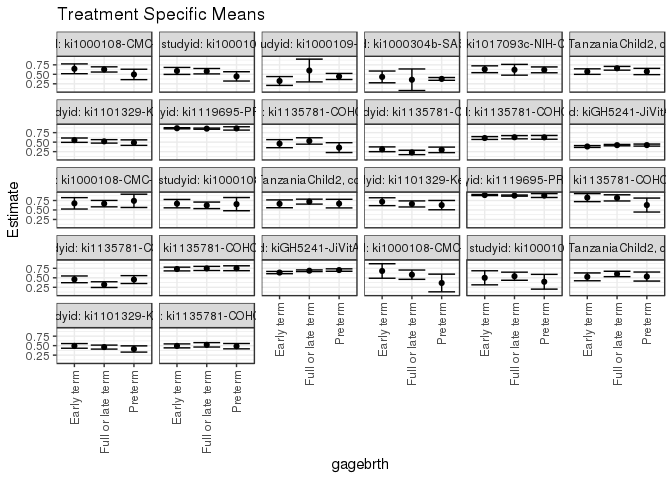

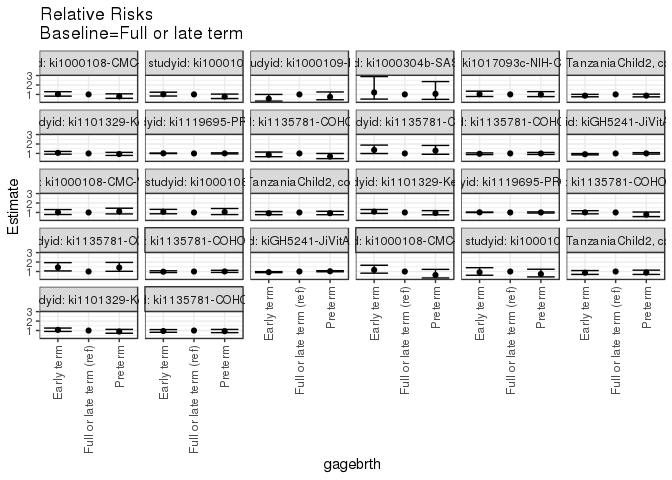

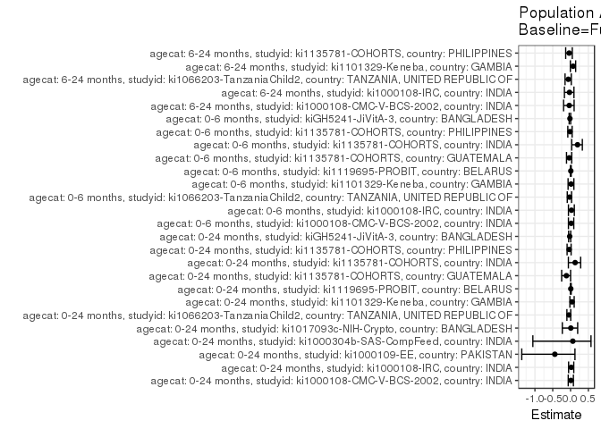

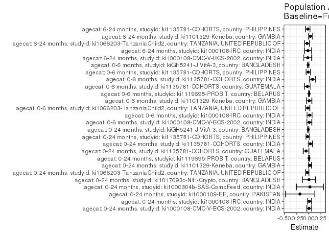

## Results Table

### Parameter: TSM

| agecat | studyid | country | intervention_level | baseline_level | estimate | ci_lower | ci_upper |
| --- | --- | --- | --- | --- | --- | --- | --- |
| 0-24 months | ki1000108-CMC-V-BCS-2002 | INDIA | Full or late term | NA | 0.6281856 | 0.5593775 | 0.6969936 |
| 0-24 months | ki1000108-CMC-V-BCS-2002 | INDIA | Preterm | NA | 0.4964194 | 0.3595221 | 0.6333168 |
| 0-24 months | ki1000108-CMC-V-BCS-2002 | INDIA | Early term | NA | 0.6449183 | 0.5161989 | 0.7736376 |
| 0-24 months | ki1000108-IRC | INDIA | Full or late term | NA | 0.5821075 | 0.5107345 | 0.6534804 |
| 0-24 months | ki1000108-IRC | INDIA | Preterm | NA | 0.4455714 | 0.3230440 | 0.5680987 |
| 0-24 months | ki1000108-IRC | INDIA | Early term | NA | 0.5889674 | 0.4973557 | 0.6805791 |
| 0-24 months | ki1000109-EE | PAKISTAN | Full or late term | NA | 0.6000000 | 0.3000972 | 0.8999028 |
| 0-24 months | ki1000109-EE | PAKISTAN | Preterm | NA | 0.4431818 | 0.3628195 | 0.5235442 |
| 0-24 months | ki1000109-EE | PAKISTAN | Early term | NA | 0.3239437 | 0.2074617 | 0.4404256 |
| 0-24 months | ki1000304b-SAS-CompFeed | INDIA | Full or late term | NA | 0.3571429 | 0.0731496 | 0.6411361 |
| 0-24 months | ki1000304b-SAS-CompFeed | INDIA | Preterm | NA | 0.3785235 | 0.3421693 | 0.4148777 |
| 0-24 months | ki1000304b-SAS-CompFeed | INDIA | Early term | NA | 0.4313725 | 0.2762267 | 0.5865184 |
| 0-24 months | ki1017093c-NIH-Crypto | BANGLADESH | Full or late term | NA | 0.6190476 | 0.4768572 | 0.7612380 |
| 0-24 months | ki1017093c-NIH-Crypto | BANGLADESH | Preterm | NA | 0.6174497 | 0.5406725 | 0.6942268 |
| 0-24 months | ki1017093c-NIH-Crypto | BANGLADESH | Early term | NA | 0.6333333 | 0.5434169 | 0.7232498 |
| 0-24 months | ki1066203-TanzaniaChild2 | TANZANIA, UNITED REPUBLIC OF | Full or late term | NA | 0.6588030 | 0.6091705 | 0.7084355 |
| 0-24 months | ki1066203-TanzaniaChild2 | TANZANIA, UNITED REPUBLIC OF | Preterm | NA | 0.5742875 | 0.4915376 | 0.6570374 |
| 0-24 months | ki1066203-TanzaniaChild2 | TANZANIA, UNITED REPUBLIC OF | Early term | NA | 0.5712974 | 0.4978477 | 0.6447471 |
| 0-24 months | ki1101329-Keneba | GAMBIA | Full or late term | NA | 0.5200837 | 0.4740887 | 0.5660787 |
| 0-24 months | ki1101329-Keneba | GAMBIA | Preterm | NA | 0.4872322 | 0.4144652 | 0.5599991 |
| 0-24 months | ki1101329-Keneba | GAMBIA | Early term | NA | 0.5516290 | 0.4944692 | 0.6087888 |
| 0-24 months | ki1119695-PROBIT | BELARUS | Full or late term | NA | 0.8554655 | 0.8407712 | 0.8701599 |
| 0-24 months | ki1119695-PROBIT | BELARUS | Preterm | NA | 0.8612683 | 0.8174966 | 0.9050400 |
| 0-24 months | ki1119695-PROBIT | BELARUS | Early term | NA | 0.8660293 | 0.8516000 | 0.8804586 |
| 0-24 months | ki1135781-COHORTS | GUATEMALA | Full or late term | NA | 0.5304924 | 0.4459838 | 0.6150010 |
| 0-24 months | ki1135781-COHORTS | GUATEMALA | Preterm | NA | 0.3560088 | 0.2262220 | 0.4857955 |
| 0-24 months | ki1135781-COHORTS | GUATEMALA | Early term | NA | 0.4598919 | 0.3537356 | 0.5660481 |
| 0-24 months | ki1135781-COHORTS | INDIA | Full or late term | NA | 0.2282502 | 0.1706356 | 0.2858648 |
| 0-24 months | ki1135781-COHORTS | INDIA | Preterm | NA | 0.2964576 | 0.2231521 | 0.3697632 |
| 0-24 months | ki1135781-COHORTS | INDIA | Early term | NA | 0.3119358 | 0.2487492 | 0.3751224 |
| 0-24 months | ki1135781-COHORTS | PHILIPPINES | Full or late term | NA | 0.6295354 | 0.5867823 | 0.6722885 |
| 0-24 months | ki1135781-COHORTS | PHILIPPINES | Preterm | NA | 0.6265811 | 0.5771194 | 0.6760427 |
| 0-24 months | ki1135781-COHORTS | PHILIPPINES | Early term | NA | 0.6083659 | 0.5710032 | 0.6457286 |
| 0-24 months | kiGH5241-JiVitA-3 | BANGLADESH | Full or late term | NA | 0.4210934 | 0.4034109 | 0.4387759 |
| 0-24 months | kiGH5241-JiVitA-3 | BANGLADESH | Preterm | NA | 0.4224745 | 0.3955641 | 0.4493849 |
| 0-24 months | kiGH5241-JiVitA-3 | BANGLADESH | Early term | NA | 0.3852558 | 0.3616777 | 0.4088339 |
| 0-6 months | ki1000108-CMC-V-BCS-2002 | INDIA | Full or late term | NA | 0.6666667 | 0.5821538 | 0.7511795 |
| 0-6 months | ki1000108-CMC-V-BCS-2002 | INDIA | Preterm | NA | 0.7407407 | 0.5657628 | 0.9157187 |
| 0-6 months | ki1000108-CMC-V-BCS-2002 | INDIA | Early term | NA | 0.6750000 | 0.5250907 | 0.8249093 |
| 0-6 months | ki1000108-IRC | INDIA | Full or late term | NA | 0.6222222 | 0.5361698 | 0.7082747 |
| 0-6 months | ki1000108-IRC | INDIA | Preterm | NA | 0.6538462 | 0.4797295 | 0.8279628 |
| 0-6 months | ki1000108-IRC | INDIA | Early term | NA | 0.6666667 | 0.5568093 | 0.7765240 |
| 0-6 months | ki1066203-TanzaniaChild2 | TANZANIA, UNITED REPUBLIC OF | Full or late term | NA | 0.7200712 | 0.6552509 | 0.7848915 |
| 0-6 months | ki1066203-TanzaniaChild2 | TANZANIA, UNITED REPUBLIC OF | Preterm | NA | 0.6676556 | 0.5543017 | 0.7810094 |
| 0-6 months | ki1066203-TanzaniaChild2 | TANZANIA, UNITED REPUBLIC OF | Early term | NA | 0.6622883 | 0.5589450 | 0.7656317 |
| 0-6 months | ki1101329-Keneba | GAMBIA | Full or late term | NA | 0.6590284 | 0.5792274 | 0.7388294 |
| 0-6 months | ki1101329-Keneba | GAMBIA | Preterm | NA | 0.6281911 | 0.5057485 | 0.7506337 |
| 0-6 months | ki1101329-Keneba | GAMBIA | Early term | NA | 0.7177621 | 0.6142413 | 0.8212829 |
| 0-6 months | ki1119695-PROBIT | BELARUS | Full or late term | NA | 0.8788067 | 0.8647937 | 0.8928197 |
| 0-6 months | ki1119695-PROBIT | BELARUS | Preterm | NA | 0.8796655 | 0.8291534 | 0.9301776 |
| 0-6 months | ki1119695-PROBIT | BELARUS | Early term | NA | 0.8931148 | 0.8794342 | 0.9067954 |
| 0-6 months | ki1135781-COHORTS | GUATEMALA | Full or late term | NA | 0.8181818 | 0.7368393 | 0.8995243 |
| 0-6 months | ki1135781-COHORTS | GUATEMALA | Preterm | NA | 0.6296296 | 0.4457667 | 0.8134926 |
| 0-6 months | ki1135781-COHORTS | GUATEMALA | Early term | NA | 0.8260870 | 0.7207224 | 0.9314515 |
| 0-6 months | ki1135781-COHORTS | INDIA | Full or late term | NA | 0.3202521 | 0.2453166 | 0.3951876 |
| 0-6 months | ki1135781-COHORTS | INDIA | Preterm | NA | 0.4534234 | 0.3497699 | 0.5570768 |
| 0-6 months | ki1135781-COHORTS | INDIA | Early term | NA | 0.4596614 | 0.3705977 | 0.5487252 |
| 0-6 months | ki1135781-COHORTS | PHILIPPINES | Full or late term | NA | 0.7470807 | 0.6925370 | 0.8016244 |
| 0-6 months | ki1135781-COHORTS | PHILIPPINES | Preterm | NA | 0.7522055 | 0.6881519 | 0.8162591 |
| 0-6 months | ki1135781-COHORTS | PHILIPPINES | Early term | NA | 0.7311987 | 0.6822694 | 0.7801280 |
| 0-6 months | kiGH5241-JiVitA-3 | BANGLADESH | Full or late term | NA | 0.6864978 | 0.6653245 | 0.7076711 |
| 0-6 months | kiGH5241-JiVitA-3 | BANGLADESH | Preterm | NA | 0.7039555 | 0.6721911 | 0.7357198 |
| 0-6 months | kiGH5241-JiVitA-3 | BANGLADESH | Early term | NA | 0.6380715 | 0.6081774 | 0.6679655 |
| 6-24 months | ki1000108-CMC-V-BCS-2002 | INDIA | Full or late term | NA | 0.5820896 | 0.4594727 | 0.7047064 |
| 6-24 months | ki1000108-CMC-V-BCS-2002 | INDIA | Preterm | NA | 0.3636364 | 0.1308138 | 0.5964590 |
| 6-24 months | ki1000108-CMC-V-BCS-2002 | INDIA | Early term | NA | 0.6800000 | 0.4890151 | 0.8709849 |
| 6-24 months | ki1000108-IRC | INDIA | Full or late term | NA | 0.5418739 | 0.4349486 | 0.6487992 |
| 6-24 months | ki1000108-IRC | INDIA | Preterm | NA | 0.3956932 | 0.2012648 | 0.5901215 |
| 6-24 months | ki1000108-IRC | INDIA | Early term | NA | 0.5001422 | 0.3148842 | 0.6854003 |
| 6-24 months | ki1066203-TanzaniaChild2 | TANZANIA, UNITED REPUBLIC OF | Full or late term | NA | 0.6011455 | 0.5302255 | 0.6720656 |
| 6-24 months | ki1066203-TanzaniaChild2 | TANZANIA, UNITED REPUBLIC OF | Preterm | NA | 0.5332484 | 0.4142166 | 0.6522802 |
| 6-24 months | ki1066203-TanzaniaChild2 | TANZANIA, UNITED REPUBLIC OF | Early term | NA | 0.5247771 | 0.4214692 | 0.6280849 |
| 6-24 months | ki1101329-Keneba | GAMBIA | Full or late term | NA | 0.4613550 | 0.4087261 | 0.5139838 |
| 6-24 months | ki1101329-Keneba | GAMBIA | Preterm | NA | 0.4117067 | 0.3297774 | 0.4936360 |
| 6-24 months | ki1101329-Keneba | GAMBIA | Early term | NA | 0.4929935 | 0.4318581 | 0.5541289 |
| 6-24 months | ki1135781-COHORTS | PHILIPPINES | Full or late term | NA | 0.5214724 | 0.4634910 | 0.5794538 |
| 6-24 months | ki1135781-COHORTS | PHILIPPINES | Preterm | NA | 0.4859813 | 0.4159761 | 0.5559865 |
| 6-24 months | ki1135781-COHORTS | PHILIPPINES | Early term | NA | 0.4936061 | 0.4414105 | 0.5458018 |

### Parameter: E(Y)

| agecat | studyid | country | intervention_level | baseline_level | estimate | ci_lower | ci_upper |
| --- | --- | --- | --- | --- | --- | --- | --- |
| 0-24 months | ki1000108-CMC-V-BCS-2002 | INDIA | NA | NA | 0.6345515 | 0.5770351 | 0.6920679 |
| 0-24 months | ki1000108-IRC | INDIA | NA | NA | 0.5942408 | 0.5412823 | 0.6471994 |
| 0-24 months | ki1000109-EE | PAKISTAN | NA | NA | 0.4163424 | 0.3511349 | 0.4815500 |
| 0-24 months | ki1000304b-SAS-CompFeed | INDIA | NA | NA | 0.3814815 | 0.3462984 | 0.4166645 |
| 0-24 months | ki1017093c-NIH-Crypto | BANGLADESH | NA | NA | 0.6237942 | 0.5698223 | 0.6777662 |
| 0-24 months | ki1066203-TanzaniaChild2 | TANZANIA, UNITED REPUBLIC OF | NA | NA | 0.6291291 | 0.5901846 | 0.6680736 |
| 0-24 months | ki1101329-Keneba | GAMBIA | NA | NA | 0.5435467 | 0.5088559 | 0.5782375 |
| 0-24 months | ki1119695-PROBIT | BELARUS | NA | NA | 0.8612051 | 0.8511051 | 0.8713052 |
| 0-24 months | ki1135781-COHORTS | GUATEMALA | NA | NA | 0.4750000 | 0.4147665 | 0.5352335 |
| 0-24 months | ki1135781-COHORTS | INDIA | NA | NA | 0.2619503 | 0.2237649 | 0.3001357 |
| 0-24 months | ki1135781-COHORTS | PHILIPPINES | NA | NA | 0.6059701 | 0.5813402 | 0.6306001 |
| 0-24 months | kiGH5241-JiVitA-3 | BANGLADESH | NA | NA | 0.4112116 | 0.3983175 | 0.4241057 |
| 0-6 months | ki1000108-CMC-V-BCS-2002 | INDIA | NA | NA | 0.6791444 | 0.6111760 | 0.7471128 |
| 0-6 months | ki1000108-IRC | INDIA | NA | NA | 0.6391304 | 0.5756367 | 0.7026242 |
| 0-6 months | ki1066203-TanzaniaChild2 | TANZANIA, UNITED REPUBLIC OF | NA | NA | 0.6993671 | 0.6481378 | 0.7505964 |
| 0-6 months | ki1101329-Keneba | GAMBIA | NA | NA | 0.6692607 | 0.6118880 | 0.7266334 |
| 0-6 months | ki1119695-PROBIT | BELARUS | NA | NA | 0.8855266 | 0.8758983 | 0.8951550 |
| 0-6 months | ki1135781-COHORTS | GUATEMALA | NA | NA | 0.7888199 | 0.7258783 | 0.8517615 |
| 0-6 months | ki1135781-COHORTS | INDIA | NA | NA | 0.3982558 | 0.3464489 | 0.4500628 |
| 0-6 months | ki1135781-COHORTS | PHILIPPINES | NA | NA | 0.7365591 | 0.7047881 | 0.7683302 |
| 0-6 months | kiGH5241-JiVitA-3 | BANGLADESH | NA | NA | 0.6746988 | 0.6589571 | 0.6904405 |
| 6-24 months | ki1000108-CMC-V-BCS-2002 | INDIA | NA | NA | 0.5614035 | 0.4645960 | 0.6582110 |
| 6-24 months | ki1000108-IRC | INDIA | NA | NA | 0.5263158 | 0.4415211 | 0.6111105 |
| 6-24 months | ki1066203-TanzaniaChild2 | TANZANIA, UNITED REPUBLIC OF | NA | NA | 0.5657143 | 0.5118874 | 0.6195411 |
| 6-24 months | ki1101329-Keneba | GAMBIA | NA | NA | 0.4971264 | 0.4573928 | 0.5368601 |
| 6-24 months | ki1135781-COHORTS | PHILIPPINES | NA | NA | 0.5016112 | 0.4676556 | 0.5355667 |

### Parameter: RR

| agecat | studyid | country | intervention_level | baseline_level | estimate | ci_lower | ci_upper |
| --- | --- | --- | --- | --- | --- | --- | --- |
| 0-24 months | ki1000108-CMC-V-BCS-2002 | INDIA | Full or late term | Full or late term | 1.0000000 | 1.0000000 | 1.0000000 |
| 0-24 months | ki1000108-CMC-V-BCS-2002 | INDIA | Preterm | Full or late term | 0.7902433 | 0.5869634 | 1.0639241 |
| 0-24 months | ki1000108-CMC-V-BCS-2002 | INDIA | Early term | Full or late term | 1.0266366 | 0.8178823 | 1.2886727 |
| 0-24 months | ki1000108-IRC | INDIA | Full or late term | Full or late term | 1.0000000 | 1.0000000 | 1.0000000 |
| 0-24 months | ki1000108-IRC | INDIA | Preterm | Full or late term | 0.7654452 | 0.5659721 | 1.0352211 |
| 0-24 months | ki1000108-IRC | INDIA | Early term | Full or late term | 1.0117846 | 0.8295665 | 1.2340278 |
| 0-24 months | ki1000109-EE | PAKISTAN | Full or late term | Full or late term | 1.0000000 | 1.0000000 | 1.0000000 |
| 0-24 months | ki1000109-EE | PAKISTAN | Preterm | Full or late term | 0.7386364 | 0.4339694 | 1.2571940 |
| 0-24 months | ki1000109-EE | PAKISTAN | Early term | Full or late term | 0.5399061 | 0.2916843 | 0.9993635 |
| 0-24 months | ki1000304b-SAS-CompFeed | INDIA | Full or late term | Full or late term | 1.0000000 | 1.0000000 | 1.0000000 |
| 0-24 months | ki1000304b-SAS-CompFeed | INDIA | Preterm | Full or late term | 1.0598658 | 0.4757869 | 2.3609635 |
| 0-24 months | ki1000304b-SAS-CompFeed | INDIA | Early term | Full or late term | 1.2078431 | 0.5046764 | 2.8907336 |
| 0-24 months | ki1017093c-NIH-Crypto | BANGLADESH | Full or late term | Full or late term | 1.0000000 | 1.0000000 | 1.0000000 |
| 0-24 months | ki1017093c-NIH-Crypto | BANGLADESH | Preterm | Full or late term | 0.9974187 | 0.7680002 | 1.2953695 |
| 0-24 months | ki1017093c-NIH-Crypto | BANGLADESH | Early term | Full or late term | 1.0230769 | 0.7807062 | 1.3406918 |
| 0-24 months | ki1066203-TanzaniaChild2 | TANZANIA, UNITED REPUBLIC OF | Full or late term | Full or late term | 1.0000000 | 1.0000000 | 1.0000000 |
| 0-24 months | ki1066203-TanzaniaChild2 | TANZANIA, UNITED REPUBLIC OF | Preterm | Full or late term | 0.8717135 | 0.7409603 | 1.0255399 |
| 0-24 months | ki1066203-TanzaniaChild2 | TANZANIA, UNITED REPUBLIC OF | Early term | Full or late term | 0.8671748 | 0.7471728 | 1.0064501 |
| 0-24 months | ki1101329-Keneba | GAMBIA | Full or late term | Full or late term | 1.0000000 | 1.0000000 | 1.0000000 |
| 0-24 months | ki1101329-Keneba | GAMBIA | Preterm | Full or late term | 0.9368342 | 0.7883174 | 1.1133310 |
| 0-24 months | ki1101329-Keneba | GAMBIA | Early term | Full or late term | 1.0606542 | 0.9263095 | 1.2144834 |
| 0-24 months | ki1119695-PROBIT | BELARUS | Full or late term | Full or late term | 1.0000000 | 1.0000000 | 1.0000000 |
| 0-24 months | ki1119695-PROBIT | BELARUS | Preterm | Full or late term | 1.0067832 | 0.9541976 | 1.0622668 |
| 0-24 months | ki1119695-PROBIT | BELARUS | Early term | Full or late term | 1.0123486 | 0.9884110 | 1.0368659 |
| 0-24 months | ki1135781-COHORTS | GUATEMALA | Full or late term | Full or late term | 1.0000000 | 1.0000000 | 1.0000000 |
| 0-24 months | ki1135781-COHORTS | GUATEMALA | Preterm | Full or late term | 0.6710911 | 0.4509070 | 0.9987944 |
| 0-24 months | ki1135781-COHORTS | GUATEMALA | Early term | Full or late term | 0.8669151 | 0.6554373 | 1.1466265 |
| 0-24 months | ki1135781-COHORTS | INDIA | Full or late term | Full or late term | 1.0000000 | 1.0000000 | 1.0000000 |
| 0-24 months | ki1135781-COHORTS | INDIA | Preterm | Full or late term | 1.2988274 | 0.9135061 | 1.8466791 |
| 0-24 months | ki1135781-COHORTS | INDIA | Early term | Full or late term | 1.3666396 | 0.9920621 | 1.8826481 |
| 0-24 months | ki1135781-COHORTS | PHILIPPINES | Full or late term | Full or late term | 1.0000000 | 1.0000000 | 1.0000000 |
| 0-24 months | ki1135781-COHORTS | PHILIPPINES | Preterm | Full or late term | 0.9953071 | 0.8969915 | 1.1043986 |
| 0-24 months | ki1135781-COHORTS | PHILIPPINES | Early term | Full or late term | 0.9663728 | 0.8817839 | 1.0590762 |
| 0-24 months | kiGH5241-JiVitA-3 | BANGLADESH | Full or late term | Full or late term | 1.0000000 | 1.0000000 | 1.0000000 |
| 0-24 months | kiGH5241-JiVitA-3 | BANGLADESH | Preterm | Full or late term | 1.0032797 | 0.9298404 | 1.0825192 |
| 0-24 months | kiGH5241-JiVitA-3 | BANGLADESH | Early term | Full or late term | 0.9148940 | 0.8496690 | 0.9851259 |
| 0-6 months | ki1000108-CMC-V-BCS-2002 | INDIA | Full or late term | Full or late term | 1.0000000 | 1.0000000 | 1.0000000 |
| 0-6 months | ki1000108-CMC-V-BCS-2002 | INDIA | Preterm | Full or late term | 1.1111111 | 0.8498176 | 1.4527446 |
| 0-6 months | ki1000108-CMC-V-BCS-2002 | INDIA | Early term | Full or late term | 1.0125000 | 0.7840402 | 1.3075303 |
| 0-6 months | ki1000108-IRC | INDIA | Full or late term | Full or late term | 1.0000000 | 1.0000000 | 1.0000000 |
| 0-6 months | ki1000108-IRC | INDIA | Preterm | Full or late term | 1.0508242 | 0.7784047 | 1.4185827 |
| 0-6 months | ki1000108-IRC | INDIA | Early term | Full or late term | 1.0714286 | 0.8640328 | 1.3286061 |
| 0-6 months | ki1066203-TanzaniaChild2 | TANZANIA, UNITED REPUBLIC OF | Full or late term | Full or late term | 1.0000000 | 1.0000000 | 1.0000000 |
| 0-6 months | ki1066203-TanzaniaChild2 | TANZANIA, UNITED REPUBLIC OF | Preterm | Full or late term | 0.9272077 | 0.7655027 | 1.1230713 |
| 0-6 months | ki1066203-TanzaniaChild2 | TANZANIA, UNITED REPUBLIC OF | Early term | Full or late term | 0.9197540 | 0.7689791 | 1.1000914 |
| 0-6 months | ki1101329-Keneba | GAMBIA | Full or late term | Full or late term | 1.0000000 | 1.0000000 | 1.0000000 |
| 0-6 months | ki1101329-Keneba | GAMBIA | Preterm | Full or late term | 0.9532079 | 0.7593487 | 1.1965588 |
| 0-6 months | ki1101329-Keneba | GAMBIA | Early term | Full or late term | 1.0891217 | 0.9030584 | 1.3135208 |
| 0-6 months | ki1119695-PROBIT | BELARUS | Full or late term | Full or late term | 1.0000000 | 1.0000000 | 1.0000000 |
| 0-6 months | ki1119695-PROBIT | BELARUS | Preterm | Full or late term | 1.0009772 | 0.9430699 | 1.0624402 |
| 0-6 months | ki1119695-PROBIT | BELARUS | Early term | Full or late term | 1.0162812 | 0.9940608 | 1.0389984 |
| 0-6 months | ki1135781-COHORTS | GUATEMALA | Full or late term | Full or late term | 1.0000000 | 1.0000000 | 1.0000000 |
| 0-6 months | ki1135781-COHORTS | GUATEMALA | Preterm | Full or late term | 0.7695473 | 0.5652821 | 1.0476239 |
| 0-6 months | ki1135781-COHORTS | GUATEMALA | Early term | Full or late term | 1.0096618 | 0.8589016 | 1.1868846 |
| 0-6 months | ki1135781-COHORTS | INDIA | Full or late term | Full or late term | 1.0000000 | 1.0000000 | 1.0000000 |
| 0-6 months | ki1135781-COHORTS | INDIA | Preterm | Full or late term | 1.4158324 | 1.0225608 | 1.9603544 |
| 0-6 months | ki1135781-COHORTS | INDIA | Early term | Full or late term | 1.4353111 | 1.0614919 | 1.9407760 |
| 0-6 months | ki1135781-COHORTS | PHILIPPINES | Full or late term | Full or late term | 1.0000000 | 1.0000000 | 1.0000000 |
| 0-6 months | ki1135781-COHORTS | PHILIPPINES | Preterm | Full or late term | 1.0068598 | 0.9001466 | 1.1262240 |
| 0-6 months | ki1135781-COHORTS | PHILIPPINES | Early term | Full or late term | 0.9787413 | 0.8865811 | 1.0804816 |
| 0-6 months | kiGH5241-JiVitA-3 | BANGLADESH | Full or late term | Full or late term | 1.0000000 | 1.0000000 | 1.0000000 |
| 0-6 months | kiGH5241-JiVitA-3 | BANGLADESH | Preterm | Full or late term | 1.0254300 | 0.9710751 | 1.0828274 |
| 0-6 months | kiGH5241-JiVitA-3 | BANGLADESH | Early term | Full or late term | 0.9294588 | 0.8789178 | 0.9829061 |
| 6-24 months | ki1000108-CMC-V-BCS-2002 | INDIA | Full or late term | Full or late term | 1.0000000 | 1.0000000 | 1.0000000 |
| 6-24 months | ki1000108-CMC-V-BCS-2002 | INDIA | Preterm | Full or late term | 0.6247086 | 0.3184160 | 1.2256319 |
| 6-24 months | ki1000108-CMC-V-BCS-2002 | INDIA | Early term | Full or late term | 1.1682051 | 0.8223605 | 1.6594951 |
| 6-24 months | ki1000108-IRC | INDIA | Full or late term | Full or late term | 1.0000000 | 1.0000000 | 1.0000000 |
| 6-24 months | ki1000108-IRC | INDIA | Preterm | Full or late term | 0.7302311 | 0.4296797 | 1.2410117 |
| 6-24 months | ki1000108-IRC | INDIA | Early term | Full or late term | 0.9229864 | 0.6068374 | 1.4038420 |
| 6-24 months | ki1066203-TanzaniaChild2 | TANZANIA, UNITED REPUBLIC OF | Full or late term | Full or late term | 1.0000000 | 1.0000000 | 1.0000000 |
| 6-24 months | ki1066203-TanzaniaChild2 | TANZANIA, UNITED REPUBLIC OF | Preterm | Full or late term | 0.8870538 | 0.6891314 | 1.1418207 |
| 6-24 months | ki1066203-TanzaniaChild2 | TANZANIA, UNITED REPUBLIC OF | Early term | Full or late term | 0.8729618 | 0.6939262 | 1.0981892 |
| 6-24 months | ki1101329-Keneba | GAMBIA | Full or late term | Full or late term | 1.0000000 | 1.0000000 | 1.0000000 |
| 6-24 months | ki1101329-Keneba | GAMBIA | Preterm | Full or late term | 0.8923860 | 0.7109574 | 1.1201132 |
| 6-24 months | ki1101329-Keneba | GAMBIA | Early term | Full or late term | 1.0685775 | 0.9049529 | 1.2617869 |
| 6-24 months | ki1135781-COHORTS | PHILIPPINES | Full or late term | Full or late term | 1.0000000 | 1.0000000 | 1.0000000 |
| 6-24 months | ki1135781-COHORTS | PHILIPPINES | Preterm | Full or late term | 0.9319406 | 0.7768892 | 1.1179372 |
| 6-24 months | ki1135781-COHORTS | PHILIPPINES | Early term | Full or late term | 0.9465624 | 0.8119141 | 1.1035408 |

### Parameter: PAR

| agecat | studyid | country | intervention_level | baseline_level | estimate | ci_lower | ci_upper |
| --- | --- | --- | --- | --- | --- | --- | --- |
| 0-24 months | ki1000108-CMC-V-BCS-2002 | INDIA | Full or late term | NA | 0.0063659 | -0.0397620 | 0.0524939 |
| 0-24 months | ki1000108-IRC | INDIA | Full or late term | NA | 0.0121333 | -0.0308560 | 0.0551227 |
| 0-24 months | ki1000109-EE | PAKISTAN | Full or late term | NA | -0.1836576 | -0.4793385 | 0.1120233 |
| 0-24 months | ki1000304b-SAS-CompFeed | INDIA | Full or late term | NA | 0.0243386 | -0.2569276 | 0.3056048 |
| 0-24 months | ki1017093c-NIH-Crypto | BANGLADESH | Full or late term | NA | 0.0047466 | -0.1283808 | 0.1378740 |
| 0-24 months | ki1066203-TanzaniaChild2 | TANZANIA, UNITED REPUBLIC OF | Full or late term | NA | -0.0296739 | -0.0634556 | 0.0041078 |
| 0-24 months | ki1101329-Keneba | GAMBIA | Full or late term | NA | 0.0234630 | -0.0093523 | 0.0562783 |
| 0-24 months | ki1119695-PROBIT | BELARUS | Full or late term | NA | 0.0057396 | -0.0045375 | 0.0160168 |
| 0-24 months | ki1135781-COHORTS | GUATEMALA | Full or late term | NA | -0.0554924 | -0.1145174 | 0.0035326 |
| 0-24 months | ki1135781-COHORTS | INDIA | Full or late term | NA | 0.0337001 | -0.0111813 | 0.0785814 |
| 0-24 months | ki1135781-COHORTS | PHILIPPINES | Full or late term | NA | -0.0235653 | -0.0579593 | 0.0108288 |
| 0-24 months | kiGH5241-JiVitA-3 | BANGLADESH | Full or late term | NA | -0.0098818 | -0.0220289 | 0.0022653 |
| 0-6 months | ki1000108-CMC-V-BCS-2002 | INDIA | Full or late term | NA | 0.0124777 | -0.0384437 | 0.0633991 |
| 0-6 months | ki1000108-IRC | INDIA | Full or late term | NA | 0.0169082 | -0.0354403 | 0.0692567 |
| 0-6 months | ki1066203-TanzaniaChild2 | TANZANIA, UNITED REPUBLIC OF | Full or late term | NA | -0.0207041 | -0.0633344 | 0.0219262 |
| 0-6 months | ki1101329-Keneba | GAMBIA | Full or late term | NA | 0.0102323 | -0.0442952 | 0.0647598 |
| 0-6 months | ki1119695-PROBIT | BELARUS | Full or late term | NA | 0.0067199 | -0.0029868 | 0.0164267 |
| 0-6 months | ki1135781-COHORTS | GUATEMALA | Full or late term | NA | -0.0293619 | -0.0871996 | 0.0284757 |
| 0-6 months | ki1135781-COHORTS | INDIA | Full or late term | NA | 0.0780037 | 0.0191060 | 0.1369013 |
| 0-6 months | ki1135781-COHORTS | PHILIPPINES | Full or late term | NA | -0.0105215 | -0.0554272 | 0.0343841 |
| 0-6 months | kiGH5241-JiVitA-3 | BANGLADESH | Full or late term | NA | -0.0117990 | -0.0265548 | 0.0029567 |
| 6-24 months | ki1000108-CMC-V-BCS-2002 | INDIA | Full or late term | NA | -0.0206860 | -0.1028182 | 0.0614461 |
| 6-24 months | ki1000108-IRC | INDIA | Full or late term | NA | -0.0155581 | -0.0854811 | 0.0543649 |
| 6-24 months | ki1066203-TanzaniaChild2 | TANZANIA, UNITED REPUBLIC OF | Full or late term | NA | -0.0354312 | -0.0847681 | 0.0139056 |
| 6-24 months | ki1101329-Keneba | GAMBIA | Full or late term | NA | 0.0357715 | -0.0011537 | 0.0726967 |
| 6-24 months | ki1135781-COHORTS | PHILIPPINES | Full or late term | NA | -0.0198612 | -0.0663470 | 0.0266245 |

### Parameter: PAF

| agecat | studyid | country | intervention_level | baseline_level | estimate | ci_lower | ci_upper |
| --- | --- | --- | --- | --- | --- | --- | --- |
| 0-24 months | ki1000108-CMC-V-BCS-2002 | INDIA | Full or late term | NA | 0.0100322 | -0.0652738 | 0.0800146 |
| 0-24 months | ki1000108-IRC | INDIA | Full or late term | NA | 0.0204182 | -0.0548777 | 0.0903396 |
| 0-24 months | ki1000109-EE | PAKISTAN | Full or late term | NA | -0.4411215 | -1.3695376 | 0.1235289 |
| 0-24 months | ki1000304b-SAS-CompFeed | INDIA | Full or late term | NA | 0.0638003 | -1.0580120 | 0.5741182 |
| 0-24 months | ki1017093c-NIH-Crypto | BANGLADESH | Full or late term | NA | 0.0076092 | -0.2304690 | 0.1996227 |
| 0-24 months | ki1066203-TanzaniaChild2 | TANZANIA, UNITED REPUBLIC OF | Full or late term | NA | -0.0471666 | -0.1025730 | 0.0054555 |
| 0-24 months | ki1101329-Keneba | GAMBIA | Full or late term | NA | 0.0431665 | -0.0190059 | 0.1015455 |
| 0-24 months | ki1119695-PROBIT | BELARUS | Full or late term | NA | 0.0066647 | -0.0053442 | 0.0185301 |
| 0-24 months | ki1135781-COHORTS | GUATEMALA | Full or late term | NA | -0.1168261 | -0.2491813 | 0.0015056 |
| 0-24 months | ki1135781-COHORTS | INDIA | Full or late term | NA | 0.1286506 | -0.0609205 | 0.2843481 |
| 0-24 months | ki1135781-COHORTS | PHILIPPINES | Full or late term | NA | -0.0388885 | -0.0972118 | 0.0163346 |
| 0-24 months | kiGH5241-JiVitA-3 | BANGLADESH | Full or late term | NA | -0.0240309 | -0.0540135 | 0.0050988 |
| 0-6 months | ki1000108-CMC-V-BCS-2002 | INDIA | Full or late term | NA | 0.0183727 | -0.0595480 | 0.0905630 |
| 0-6 months | ki1000108-IRC | INDIA | Full or late term | NA | 0.0264550 | -0.0593125 | 0.1052784 |
| 0-6 months | ki1066203-TanzaniaChild2 | TANZANIA, UNITED REPUBLIC OF | Full or late term | NA | -0.0296041 | -0.0925673 | 0.0297307 |
| 0-6 months | ki1101329-Keneba | GAMBIA | Full or late term | NA | 0.0152889 | -0.0696857 | 0.0935133 |
| 0-6 months | ki1119695-PROBIT | BELARUS | Full or late term | NA | 0.0075886 | -0.0034382 | 0.0184943 |
| 0-6 months | ki1135781-COHORTS | GUATEMALA | Full or late term | NA | -0.0372226 | -0.1135640 | 0.0338851 |
| 0-6 months | ki1135781-COHORTS | INDIA | Full or late term | NA | 0.1958633 | 0.0335613 | 0.3309085 |
| 0-6 months | ki1135781-COHORTS | PHILIPPINES | Full or late term | NA | -0.0142847 | -0.0771360 | 0.0448992 |
| 0-6 months | kiGH5241-JiVitA-3 | BANGLADESH | Full or late term | NA | -0.0174879 | -0.0396141 | 0.0041674 |
| 6-24 months | ki1000108-CMC-V-BCS-2002 | INDIA | Full or late term | NA | -0.0368470 | -0.1946251 | 0.1000928 |
| 6-24 months | ki1000108-IRC | INDIA | Full or late term | NA | -0.0295604 | -0.1717588 | 0.0953815 |
| 6-24 months | ki1066203-TanzaniaChild2 | TANZANIA, UNITED REPUBLIC OF | Full or late term | NA | -0.0626310 | -0.1541083 | 0.0215956 |
| 6-24 months | ki1101329-Keneba | GAMBIA | Full or late term | NA | 0.0719565 | -0.0052491 | 0.1432325 |
| 6-24 months | ki1135781-COHORTS | PHILIPPINES | Full or late term | NA | -0.0395949 | -0.1365217 | 0.0490657 |